# Practical Machine Learning Course Project

Germán Arturo Fajardo Grimaldos

18 de diciembre de 2018

# Practical Machine Learning Course Project

## Germán Arturo Fajardo Grimaldos

## 3 de diciembre de 2018

## Background

Using devices such as Jawbone Up, Nike FuelBand, and Fitbit it is now possible to collect a large amount of data about personal activity relatively inexpensively. These type of devices are part of the quantified self movement - a group of enthusiasts who take measurements about themselves regularly to improve their health, to find patterns in their behavior, or because they are tech geeks. One thing that people regularly do is quantify how much of a particular activity they do, but they rarely quantify how well they do it. In this project, your goal will be to use data from accelerometers on the belt, forearm, arm, and dumbell of 6 participants. They were asked to perform barbell lifts correctly and incorrectly in 5 different ways. More information is available from the website here: http://groupware.les.inf.puc-rio.br/har (see the section on the Weight Lifting Exercise Dataset).

## Reading Data

The data for this project come from this source: http://groupware.les.inf.puc-rio.br/har. If you use the document you create for this class for any purpose please cite them as they have been very generous in allowing their data to be used for this kind of assignment.

```r
knitr::opts_chunk$set(echo = TRUE)

# install.packages("caret")
# install.packages("randomForest")
# install.packages("rpart");

# setting initial seed for reproduceability
set.seed(2018)
setwd("F:/Git/08_PracticalMachineLearning/Project")

##Reading and clean the training data for this project are available here:
trainurl <- "https://d396qusza40orc.cloudfront.net/predmachlearn/pml-training.csv"
trainfile <- "pml-training.csv"

if (!file.exists(trainfile)){
    download.file(url=trainurl, destfile=trainfile)
}
traindata <- read.csv(trainfile, na.strings = c("", "NA", "#DIV/0!"))


##Reading and clean the test data are available here:
testurl <- "https://d396qusza40orc.cloudfront.net/predmachlearn/pml-testing.csv"
testfile <- "pml-testing.csv"

if (!file.exists(testfile)){
    download.file(url=testurl, destfile=testfile)
}
testdata <- read.csv(testfile, na.strings = c("", "NA", "#DIV/0!"))

dim(testdata)
```

```
## [1]  20 160
```

```r
dim(traindata)
```

```
## [1] 19622   160
```

## Preparing data

```r
library(caret)
#1. Remove columns with more than 50% of itens in null,NA or zero
tr <- traindata[colMeans(is.na(traindata)) <= 0.5]
te <- testdata[colMeans(is.na(testdata)) <= 0.5]

#2. Remove unusabe columns
ctrain   <-tr[,-c(1:7)]
ctest <- te[,-c(1:7)]
dim(ctrain)
```

```
## [1] 19622    53
```

```r
dim(ctest)
```

```
## [1] 20 53
```

```r
#3. Creating new Traing data using 0.75 of original train Data
ttrains <- createDataPartition(y=ctrain$classe, p=0.75, list=FALSE)
Ttrains  <- ctrain[ttrains, ]
Ttests <- ctrain[-ttrains, ]

dim(Ttrains)
```

```
## [1] 14718    53
```

```r
dim(Ttests)
```

```
## [1] 4904   53
```

## Exploratory Data

```r
library(lattice)
library(ggplot2)

summary(Ttrains$classe)
```

```
##    A    B    C    D    E
## 4185 2848 2567 2412 2706
```

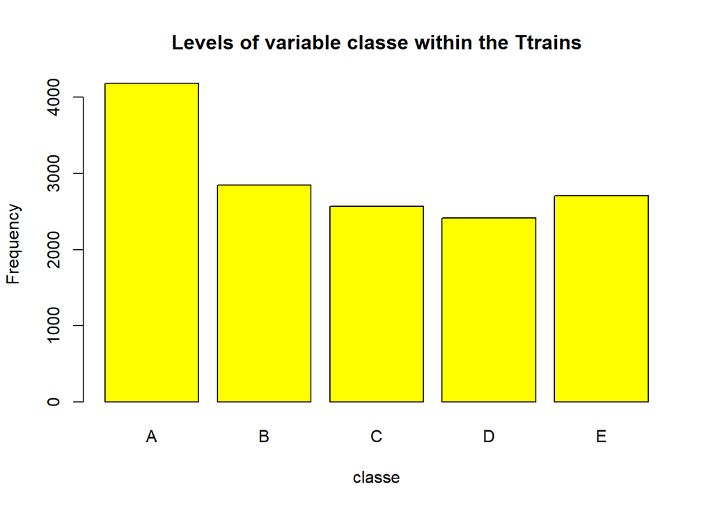

```r
#Ploting new dataset by class
plot(Ttrains$classe, col="yellow", main="Levels of variable classe within the Ttrains", xlab="classe", ylab="Frequency")
```

From the graph, it can be concluded that the dimensions of the frequencies are in the same magnitude

## Prediction model 1: Decision Tree

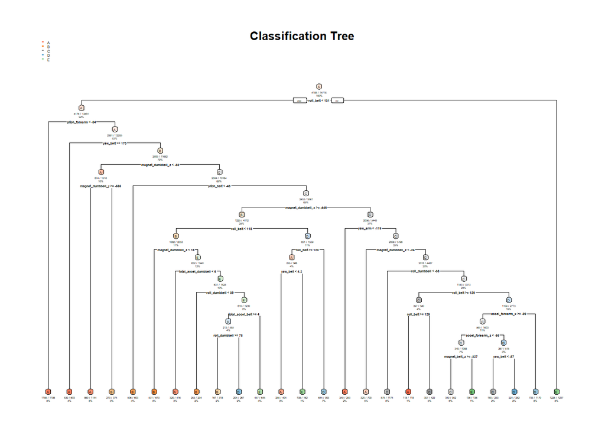

```r
library(rpart)
library(rpart.plot)

model1 <- rpart(classe ~ ., data=Ttrains, method="class")

# Predicting:
prediction1 <- predict(model1, Ttests, type = "class")

# Plot of the Decision Tree
rpart.plot(model1, main="Classification Tree", extra=102, under=TRUE, faclen=0)
```

```r
# Test results on our TestTrainingSet data set:
confusionMatrix(prediction1, Ttests$classe)
```

```
## Confusion Matrix and Statistics
##
##           Reference
## Prediction    A    B    C    D    E
##          A 1274  186   51   64   40
##          B   24  578   67   41   50
##          C   51  106  591   69   81
##          D   26   43  138  601   74
##          E   20   36    8   29  656
##
## Overall Statistics
##
##                Accuracy : 0.7545
##                  95% CI : (0.7422, 0.7665)
##     No Information Rate : 0.2845
##     P-Value [Acc > NIR] : < 2.2e-16
##
##                   Kappa : 0.688
##  Mcnemar's Test P-Value : < 2.2e-16
##
## Statistics by Class:
##
##                      Class: A Class: B Class: C Class: D Class: E
## Sensitivity            0.9133   0.6091   0.6912   0.7475   0.7281
## Specificity            0.9028   0.9540   0.9242   0.9315   0.9768
## Pos Pred Value         0.7889   0.7605   0.6581   0.6814   0.8758
## Neg Pred Value         0.9632   0.9105   0.9341   0.9495   0.9410
## Prevalence             0.2845   0.1935   0.1743   0.1639   0.1837
## Detection Rate         0.2598   0.1179   0.1205   0.1226   0.1338
## Detection Prevalence   0.3293   0.1550   0.1831   0.1799   0.1527
## Balanced Accuracy      0.9080   0.7815   0.8077   0.8395   0.8524
```

## Prediction model 2: Random Forest

```r
library(randomForest)
model2 <- randomForest(classe ~. , data=Ttrains, method="class")

# Predicting:
prediction2 <- predict(model2, Ttests, type = "class")

# Test results on Ttests data set:
confusionMatrix(prediction2, Ttests$classe)
```

```
## Confusion Matrix and Statistics
##
##           Reference
## Prediction    A    B    C    D    E
##          A 1393    2    0    0    0
##          B    2  946    3    0    0
##          C    0    1  852   11    1
##          D    0    0    0  793    0
##          E    0    0    0    0  900
##
## Overall Statistics
##
##                Accuracy : 0.9959
##                  95% CI : (0.9937, 0.9975)
##     No Information Rate : 0.2845
##     P-Value [Acc > NIR] : < 2.2e-16
##
##                   Kappa : 0.9948
##  Mcnemar's Test P-Value : NA
##
## Statistics by Class:
##
##                      Class: A Class: B Class: C Class: D Class: E
## Sensitivity            0.9986   0.9968   0.9965   0.9863   0.9989
## Specificity            0.9994   0.9987   0.9968   1.0000   1.0000
## Pos Pred Value         0.9986   0.9947   0.9850   1.0000   1.0000
## Neg Pred Value         0.9994   0.9992   0.9993   0.9973   0.9998
## Prevalence             0.2845   0.1935   0.1743   0.1639   0.1837
## Detection Rate         0.2841   0.1929   0.1737   0.1617   0.1835
## Detection Prevalence   0.2845   0.1939   0.1764   0.1617   0.1835
## Balanced Accuracy      0.9990   0.9978   0.9966   0.9932   0.9994
```

## Decision on which Prediction Model to Use:

Here is the final outcome based on the Prediction Model 2 (Random Forest) applied against the Testing dataset

# predict outcome levels on the original Testing data set using Random Forest algorithm

```r
predictfinal <- predict(model2, ctest, type="class")
predictfinal
```

```
##  1  2  3  4  5  6  7  8  9 10 11 12 13 14 15 16 17 18 19 20
##  B  A  B  A  A  E  D  B  A  A  B  C  B  A  E  E  A  B  B  B
## Levels: A B C D E
```

## References

1. http://www.dataanalytictips.com/machine-learning-predicting-quality-exercise/
2. http://groupware.les.inf.puc-rio.br/public/papers/2013.Velloso.QAR-WLE.pdf
3. https://www.researchgate.net/publication/221258784_Human_Activity_Recognition_from_Accelerometer_Data_Using_a_Wearable_Device
4. http://groupware.les.inf.puc-rio.br/public/papers/2012.Ugulino.WearableComputing.HAR.Classifier.RIBBON.pdf